# Webscraping Final Project

Maryam Khan

12/21/2021

## Overview

The purpose of this project was to extract data an API and convert it into a data frame so that we can conduct an analysis on it. For my project I chose the [**makeupAPI**](https://makeup-api.herokuapp.com) . To do a price comparison between different makeup products and brands.

## API Data Loading

I used the GET feature to connect to the API and download data into the environment. The data, however, had to be cleaned and sorted for the purpose of my analysis. Price column had to be changed into numeric form and I used the group_by features to make sub tables and made visualizations using those tables.

I used functions so that data from multiple brands would be loaded automatically in a loop by using lapply and rbindlist. This helped create my final_df table.

```
##        Brand                                    Name Price    Type Rating
## 1: covergirl              CoverGirl truBLEND Bronzer 13.99 bronzer     NA
## 2: covergirl            CoverGirl Clean Glow Bronzer  8.99 bronzer      5
## 3: covergirl  CoverGirl truBLEND Blush in Light Rose 13.99   blush     NA
## 4: covergirl CoverGirl truBLEND Blush in Medium Rose 13.99   blush      5
## 5: covergirl             CoverGirl Clean Glow Blush   8.99   blush      5
## 6: covergirl              CoverGirl Clean Glow Blush  8.99   blush     NA
```

For this project I compared only 7 brands listed below:

- Covergirl
- NYX
- Smashbox
- Benefit
- L’oreal
- Maybelline
- Revlon

To make the visualization I had to filter and group the data according to type and made separate data tables for those.

## Visualization 1

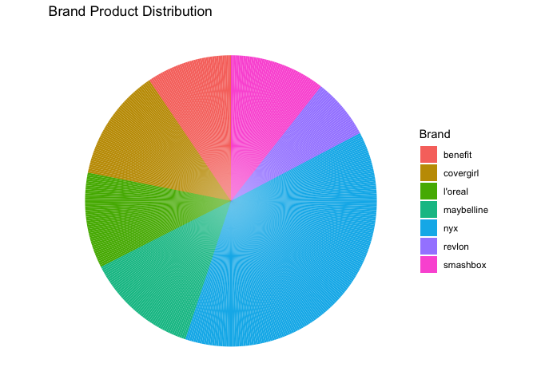

This visualization shows which brand has the most makeup products. From the pie chart we can see that the NYX has the biggest range followed by Covergirl and Maybelline.

## Visualization 2

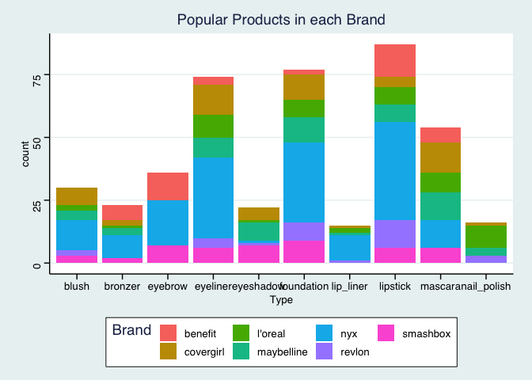

This stacked bar chart shows which product is popular in which brand. We can see that nyx dominates the makeup market for most of the products. L’oreal is more popular in nail polishes and maybelline is more popular for eyeshadows.

## Visualization 3

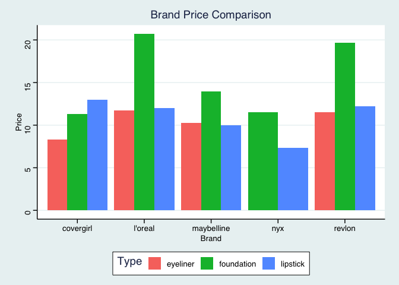

## Visualization 4

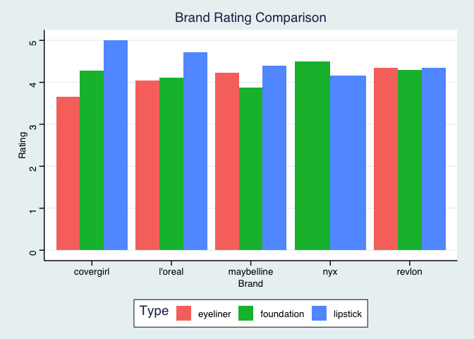

This grouped bar chart shows the rating for eyeliner, foundation and lipstick for the selected brands. Covergirl has the highest rated lipstick whereas, nyx has the lowest rated lipsticks.

## Conclusion

To conclude, this project shows us how we can compare makeup prices and rating of all makeup brands and products.